# Tekton ArgoCD CI/CD

# 1. Prelude

This is the second document of the CI/CD pipeline. This time we will use our own project from java-spring-test-p2 with slight modification (I will provide the modified version). This time we will seperate the pipeline into three parts: CI, CD, and automation part. Based on limitation and time constraint, automation part cannot be finished but will giving some guideline here and will be finished in the next document.

# 2. Setup

The following are things to be installed before the tutorial. The machine used here are specifically instructed for MAC user.

1. Virtualbox (v. 6.1)
2. Docker registry (Docker Hub)
3. Three private Github repositories (one named source, one named GitOps, and the other named maven-repo)

**Also for any public key and private key creation please refer to the previous document. Also be sure to make modifies for every url, secrets, version, imageName to your own like described in the previous document.**

# 3. Preparation

# 3.1 Install and start minikube cluster

Please refer to the previous document for installation of minikube and kubectl.

We will use following configuration for minikube (optionally):

```
  minikube config set disk-size 100000
  minikube config set container-runtime containerd
  minikube config set driver virtualbox
  minikube config set memory 8000
```

Above config will will take effect upon a minikube delete and then a minikube start.

To start minikube:

```
  minikube start
```

# 3.2 Build Image application image manually and upload to Docker Hub

Open Eclipse, and import maven project from java_project directory.

Note you need to change the your output image name according to your dockerhub repository under **build.plugins.plugin.configuration.image.name** in both pom.xml files.

- right click account-service/pom.xml -> Run as -> Maven build… and type **spring-boot:build-image -DskipTests -Dspring-boot.build-image.skip=false**
- right click service-discovery/pom.xml -> Run as -> Maven build… and type **spring-boot:build-image**

Now just use docker push command to push two local images to your online docker repository (docker hub).

Finally we need to create a frontend image.

```
  cd java_project/frontend
  docker build -t huangpen/application_img:frontend-app . (again change according to your own docker hub)
  docker push huangpen/application_img:frontend-app
```

# 3.3 change settings.xml

The settings.xml in java_project is to configure maven to use remote server as artifact repo. It contains access credential. Be sure to change username and password to your own github username and github access token. This will be used during tekton CI build

# 4. ArgoCD Deployment

Install ArgoCD:

```
  kubectl create namespace argocd

  kubectl apply -n argocd -f https://raw.githubusercontent.com/argoproj/argo-cd/stable/manifests/install.yaml
```

Wait for all the created pods to be in the ready state:

```
  kubectl get pods -n argocd -w
```

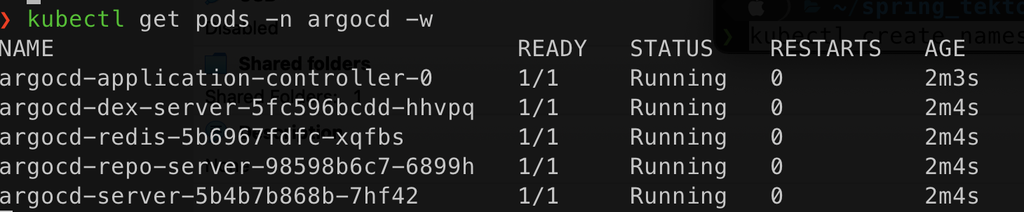

Now to access argocd UI:

```
  kubectl port-forward -n argocd svc/argocd-server 8080:443
```

You can then access to the web UI from the following url https://localhost:8080 with

```
  username: admin
  password: <kubectl get secret argocd-initial-admin-secret -n argocd -o jsonpath="{.data.password}" | base64 -d>
```

Under gitops directory apply regsecret.yaml, private-repo.yaml, and application.yaml file. This will configured dockerhub private key and setup SSH connection to GitOps repository. The application.yaml will pull any artifact from GitOps repository to spin the application pods. type the following:

```
  kubectl apply -f regsecret.yaml
  kubectl apply -f private-repo.yaml
  kubectl apply -f application.yaml
```

After several minutes during the first run, you will see the following that shows success:

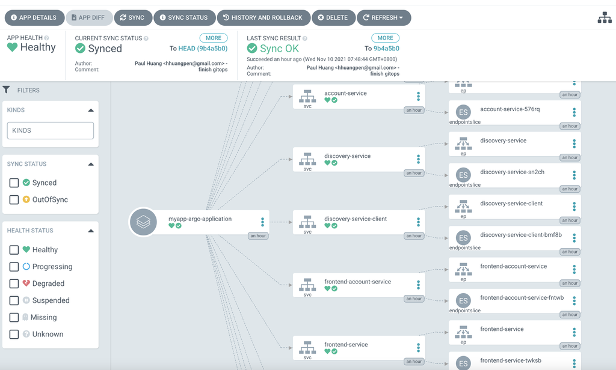

To access website service, we can type the following to see what service is exposed to NodePort:

```
  kubectl get svc -n myapp
```

We will see we can access account-service (backend), frontend-service (frontend), discovery-service (service discovery). Then we can look at the url by typing:

```
  minikube service frontend-service -n myapp --url
```

# 5. Teckton Pipeline

To install the core component of Tekton, Tekton pipeline:

```
  kubectl apply --filename https://storage.googleapis.com/tekton-releases/pipeline/latest/release.yaml
```

We will set “tekton-pipelines” to current namespace by running:

```
  kubectl config set-context --current --namespace=tekton-pipelines
```

To run a CI/CD workflow, we need to provide Tekton a Persistent Volume for storage purposes.

```
  kubectl apply -f tekton/pv_1.yaml
```

To install and run dashboard:

```
  kubectl apply --filename https://github.com/tektoncd/dashboard/releases/latest/download/tekton-dashboard-release.yaml
  kubectl --namespace tekton-pipelines port-forward svc/tekton-dashboard 9097:9097
```

Then you can access tekton dashboard UI at http://localhost:9097

Now setup service account which provides identity and secrets for processes that run in pods:

```
  kubectl apply -f tekton/regsecret.yaml
  kubectl apply -f tekton/tekton-git-ssh-secret.yaml
  kubectl apply -f tekton/serviceaccount.yaml
```

Now we can setup pipelines and tasks. However this time we will create a persistent volume claim for our pipelines so every rerun of pipeline does not need to download maven dependency again.

```
  kubectl apply -f tekton/maven-repo-pvc.yaml
  kubectl apply -f tekton/pipeline.yaml
  kubectl apply -f tekton/task-build-push.yaml
```

To execute the pipeline:

```
  kubectl create -f tekton/pipelineruns/pipelinerun.yaml
```

Note that in this tutorial, I have not completed every task and pipeline. Also, during the build-image step it will fail because I have not created an image or environment that has docker engine inside. We will defer that to the next document.

The following is the end result of our tekton pipeline so far:

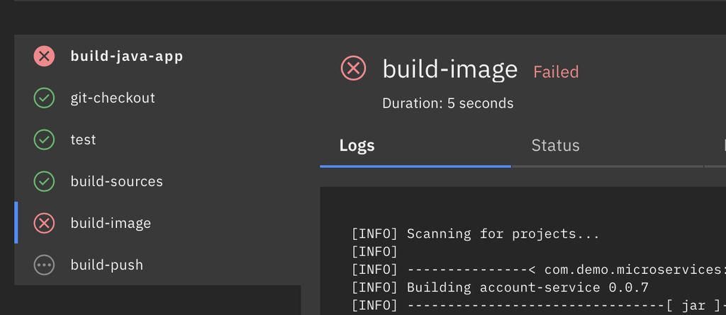

# 6. Automation

First we need to install tekton trigger kubernetes resource:

```
  kubectl apply -f https://storage.googleapis.com/tekton-releases/triggers/latest/release.yaml
```

Then we will create trigger secret for github and serviceaccount that use the secret:

```
  kubectl apply -f tekton/pipelinetriggers/github-trigger-secret.yaml
  kubectl apply -f tekton/pipelinetriggers/serviceaccount.yaml
```

Next we will need trigger template and trigger binding. A TriggerTemplate is a resource that specifies a blueprint for the resource, such as a TaskRun or PipelineRun, that you want to instantiate and/or execute when your EventListener detects an event. And TriggerBinding is responsible to bind the Event payload with Template Parameters.

```
  kubectl apply -f tekton/pipelinetriggers/triggerTemplate.yaml
```

Then we need actual a eventlistener, which is primary interace for external sources to send events, that will trigger the creation of Tekton resources defined as part of the TriggerTemplate.

```
  kubectl apply -f tekton/pipelinetriggers/eventlistener.yaml
  kubectl get pods,svc -leventlistener=github-listener-interceptor
```

Then you will see eventlistener create a kubernetes service:

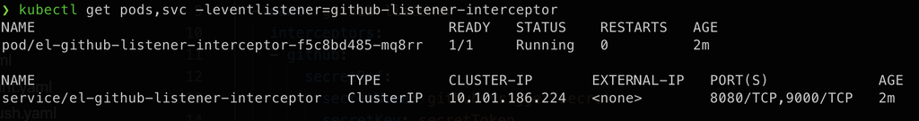

If you need the EventListner service to be available outside of the cluster thereby you can use them as part of the webhook, the service el-github-listener-interceptor needs to be exposed via Ingress. However we will just expose through node port since we do not have static ip in which connect to pubic github webhook. We will use local git server in the production environment, and we will defer this to the next document.

```
  kubectl apply -f event-nodeport.yaml
  minikube service github-eventlistener-service -n tekton-pipelines --url
```

When you access through the web, you can see a event trigger.

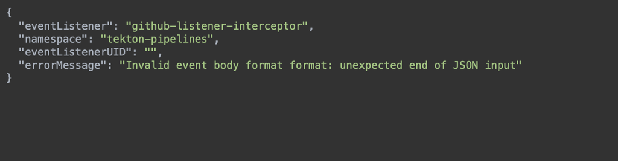

This is the end of the second document. In this document we separate the concern into three parts. We dissect problems into manageable components albeit incomplete due to network and time constraint. We will complete full CI/CD pipeline in the final document.